# Stewart Platform: Inverse Kinematics

EE0849 Introduction to Robotics

Basri Erdogan

# Part 1: What is a Stewart Platform?

## Today’s Goal

**In 45 minutes, you will:**

1. Understand how a Stewart platform differs from a serial robot arm
2. Derive the inverse kinematics — from desired pose to actuator commands
3. See why IK is *easy* for parallel robots (the opposite of serial!)

**Prerequisites:** Rotation matrices (W01), Homogeneous transformations (W02)

## The Stewart Platform

A **parallel manipulator** with:

- Fixed **base** plate
- Movable **platform** plate
- **Six legs** connecting them via joints

All six legs work **simultaneously** to position and orient the platform in **6 DOF**:

- Translations: $t_x, t_y, t_z$
- Rotations: roll $\phi$, pitch $\theta$, yaw $\psi$

**Applications:**

- Flight simulators
- Precision machining
- Telescope pointing
- Motion platforms (racing, VR)
- Surgical robots

## Parallel vs. Serial — The Key Insight

| Property | Serial (e.g., 6R robot arm) | Parallel (e.g., Stewart platform) |
| --- | --- | --- |
| Structure | Open kinematic chain | Closed kinematic chains |
| Workspace | Large | Small but precise |
| Payload | Lower | Higher (shared across legs) |
| Stiffness | Lower | Higher |
| **Forward Kinematics** | **Easy** — multiply DH matrices | **Hard** — solve polynomial system |
| **Inverse Kinematics** | **Hard** — multiple solutions | **Easy** — closed-form! |

> For parallel robots, **IK and FK swap difficulty** compared to serial robots.

This is the central message of today’s lecture.

# Part 2: Platform Geometry

## Coordinate Frames

We define two frames:

- **Base frame** $\{B\}$: Fixed at the center of the base plate, $z$ pointing up
- **Platform frame** $\{P\}$: At the center of the platform, moves with it

At the **home position** (no command), $\{P\}$ sits directly above $\{B\}$ at height $z_0$.

The transformation from $\{P\}$ to $\{B\}$ is exactly the **change-of-frame** from W01:

$$\mathbf{p}^{B} = \mathbf{R}\,\mathbf{p}^{P} + \mathbf{T} + \mathbf{H}$$

where $\mathbf{H} = [0, 0, z_0]^T$.

## Anchor Placement

Both base and platform have **6 anchor points** arranged as **3 pairs** on a circle.

Pair $k$ ($k=0,1,2$) is centered at angle:

$$\varphi_k = \frac{\pi}{6} + k \cdot \frac{2\pi}{3}$$

Within each pair, anchors offset by $\pm\gamma$:

$$\psi_{B,\,2k} = \varphi_k + \gamma_B, \quad \psi_{B,\,2k+1} = \varphi_k - \gamma_B$$

$$\psi_{P,\,2k} = \varphi_k + \gamma_P, \quad \psi_{P,\,2k+1} = \varphi_k - \gamma_P$$

**Design parameter:**

When $\gamma_P \gg \gamma_B$, the platform anchors spread apart while the base anchors stay close.

This creates the **criss-cross leg pattern**.

**Parameters for our example:**

| Symbol | Value |
| --- | --- |
| $r_B$ | 80 mm |
| $r_P$ | 50 mm |
| $\gamma_B$ | 12° |
| $\gamma_P$ | 45° |

## Anchor Layout — Top-Down View

- Gray squares: base anchors $\mathbf{b}_k$ on the outer circle ($r_B = 80$ mm)
- Blue circles: platform anchors $\mathbf{p}_k$ on the inner circle ($r_P = 50$ mm)
- Each leg $k$ connects $\mathbf{b}_k$ to $\mathbf{p}_k$

Notice the criss-cross pattern — adjacent platform anchors from *different* pairs end up near each other.

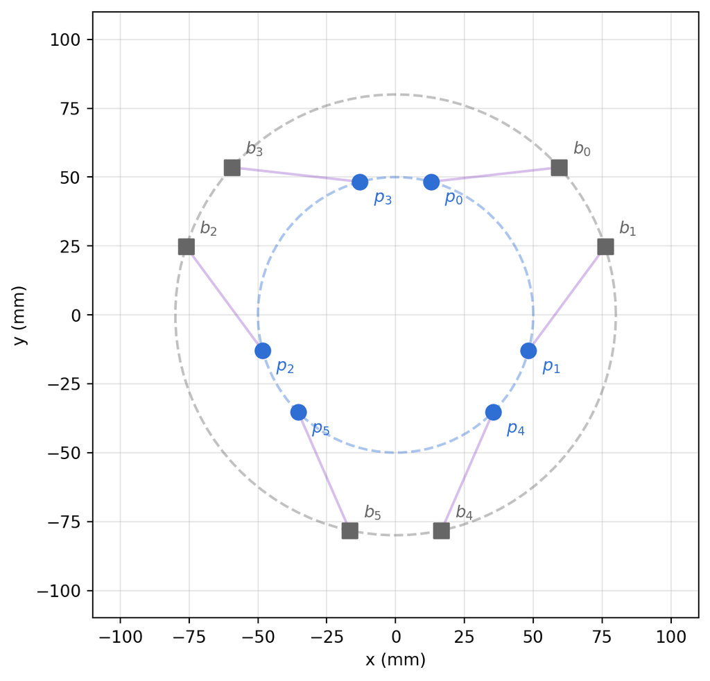

# Part 3: Stage 1 — Linear Actuator IK

## The Easy Case

Imagine each leg is a **telescoping linear actuator** (variable length).

**Problem:** Given desired pose $(\mathbf{T}, \mathbf{R})$, find each leg’s length $L_k$.

**Strategy:** Trace the vector chain from base anchor to platform anchor.

## The Vector Chain

For leg $k$, we need the vector from $\mathbf{b}_k$ to the platform anchor in the base frame:

**Step 1:** Platform anchor in $\{B\}$:

$$\mathbf{p}_k^{B} = \underbrace{\color{#2f6ed3}{\mathbf{T} + \mathbf{H}}}_{\text{where }\{P\}\text{ origin is}} + \underbrace{\color{#f39c12}{\mathbf{R}\,\mathbf{p}_k}}_{\text{rotated anchor offset}}$$

**Step 2:** Subtract the base anchor:

$$\boxed{\boldsymbol{\ell}_k = \color{#2f6ed3}{\mathbf{T} + \mathbf{H}} + \color{#f39c12}{\mathbf{R}\,\mathbf{p}_k} - \color{#666666}{\mathbf{b}_k}}$$

**Step 3:** Leg length:

$$L_k = \|\boldsymbol{\ell}_k\|$$

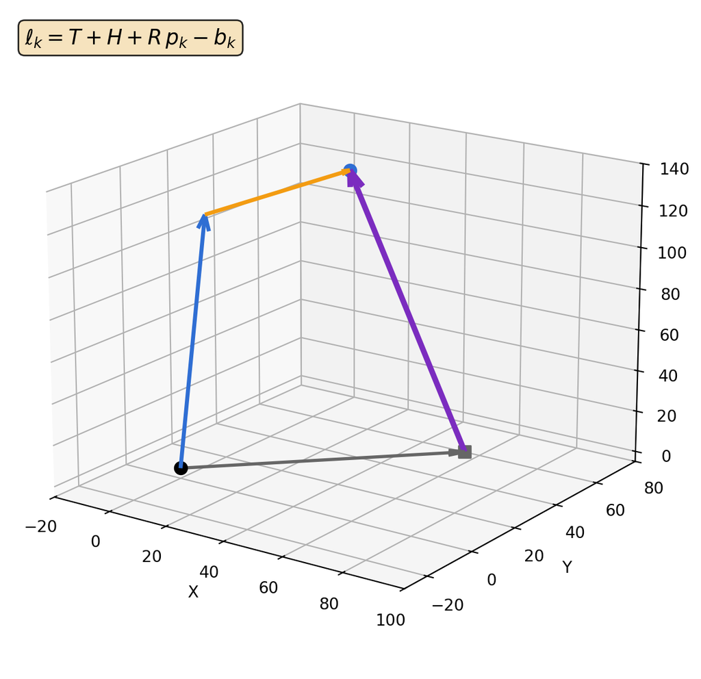

## Linear IK — Full Platform View

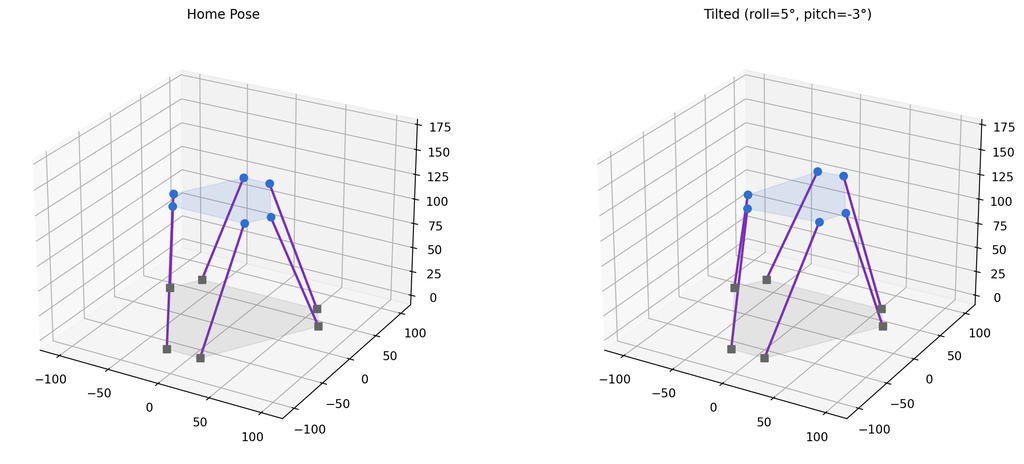

Three lines of math → complete IK for linear actuators. **But real platforms use servos…**

# Part 4: Stage 2 — Rotational Servo IK

## What Changes?

Each leg is now **two rigid links:**

1. A **servo horn** of fixed length $a$, rotating by angle $\alpha_k$
2. A **connecting rod** of fixed length $s$, connecting horn tip to platform anchor

**The unknown:** servo angle $\alpha_k$

**The constraint:** the rod must reach the platform anchor

$$\|\boldsymbol{\ell}_k - \mathbf{h}_k\| = s$$

**Horn tip position** (relative to base anchor):

$$\mathbf{h}_k(\alpha_k) = a \begin{bmatrix} \cos\alpha_k \cos\beta_k \\ \cos\alpha_k \sin\beta_k \\ \sin\alpha_k \end{bmatrix}$$

- $\beta_k$: servo shaft orientation angle
- At $\alpha_k = 0$: horn lies flat in the base plane

## Visualizing One Leg

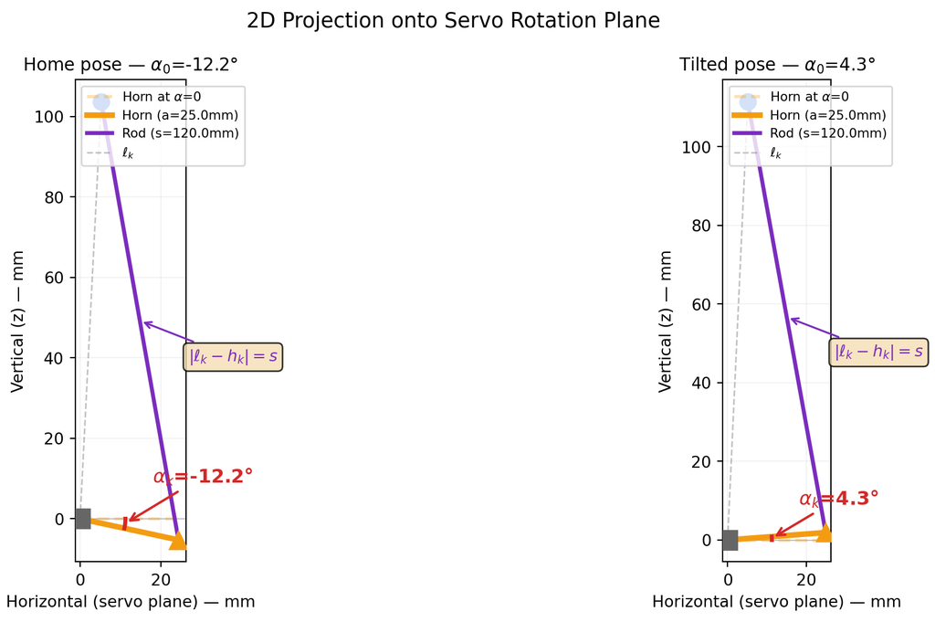

## Deriving $\alpha_k$ — Step 1: The Constraint

Start from the rod length constraint:

$$\|\boldsymbol{\ell}_k - \mathbf{h}_k\|^2 = s^2$$

Expand using $\|a-b\|^2 = \|a\|^2 - 2\,a\cdot b + \|b\|^2$:

$$\|\boldsymbol{\ell}_k\|^2 - 2\,\boldsymbol{\ell}_k \cdot \mathbf{h}_k + \underbrace{\|\mathbf{h}_k\|^2}_{= a^2} = s^2$$

Rearrange:

$$\underbrace{\|\boldsymbol{\ell}_k\|^2 + a^2 - s^2}_{g_k} = 2\,\boldsymbol{\ell}_k \cdot \mathbf{h}_k$$

## Deriving $\alpha_k$ — Step 2: Expand the Dot Product

Write $\boldsymbol{\ell}_k = [\ell_x, \ell_y, \ell_z]^T$ and substitute $\mathbf{h}_k$:

$$2\,\boldsymbol{\ell}_k \cdot \mathbf{h}_k = 2a\big(\ell_x \cos\alpha_k \cos\beta_k + \ell_y \cos\alpha_k \sin\beta_k + \ell_z \sin\alpha_k\big)$$

Group by $\sin\alpha_k$ and $\cos\alpha_k$:

$$g_k = \underbrace{2a\,\ell_z}_{e_k} \sin\alpha_k + \underbrace{2a(\ell_x \cos\beta_k + \ell_y \sin\beta_k)}_{f_k} \cos\alpha_k$$

**Summary of auxiliary variables:**

| Variable | Formula | Meaning |
| --- | --- | --- |
| $g_k$ | $\\|\boldsymbol{\ell}_k\\|^2 + a^2 - s^2$ | Geometric mismatch |
| $e_k$ | $2a\,\ell_z$ | Vertical component |
| $f_k$ | $2a(\ell_x \cos\beta_k + \ell_y \sin\beta_k)$ | Horizontal projection |

## Deriving $\alpha_k$ — Step 3: Harmonic Identity

We have: $\quad g_k = e_k \sin\alpha_k + f_k \cos\alpha_k$

Apply the **harmonic identity** (same idea as phasor addition in circuits):

$$e \sin\alpha + f \cos\alpha = \sqrt{e^2 + f^2}\;\sin\!\big(\alpha + \arctan2(f, e)\big)$$

Therefore:

$$\sin\!\big(\alpha_k + \arctan2(f_k, e_k)\big) = \frac{g_k}{\sqrt{e_k^2 + f_k^2}}$$

**Solve for $\alpha_k$:**

$$\boxed{\alpha_k = \arcsin\!\left(\frac{g_k}{\sqrt{e_k^2 + f_k^2}}\right) - \arctan2(f_k, e_k)}$$

## When Does the Solution Exist?

The $\arcsin$ argument must be in $[-1, 1]$:

$$\left|\frac{g_k}{\sqrt{e_k^2 + f_k^2}}\right| \leq 1$$

When violated → the pose is **outside the workspace**.

The horn and rod physically cannot reach the target anchor position.

> This gives us a simple **workspace test**: compute $g_k / \sqrt{e_k^2 + f_k^2}$ for all 6 legs. If any exceeds $\pm 1$, the pose is unreachable.

## Full Platform — Rotational Servos

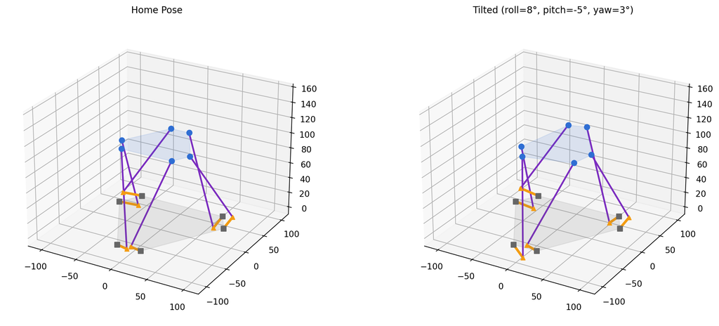

Orange = servo horns, Purple = connecting rods

# Part 5: Workspace Analysis

## Mapping the Reachable Workspace

Sweep through poses and check if $|g_k / \sqrt{e_k^2 + f_k^2}| \leq 1$ for all 6 legs:

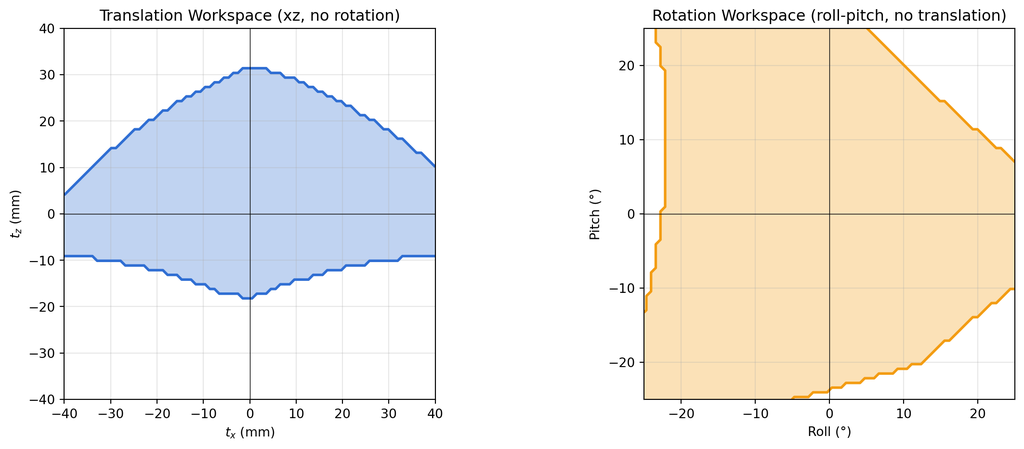

The workspace is **small but precisely controllable** — a hallmark of parallel mechanisms.

# Part 6: Summary & Discussion

## IK Algorithm Summary

Given desired pose $(\mathbf{T}, \mathbf{R})$:

**1.** Compute leg vectors (same as linear IK):
$$\boldsymbol{\ell}_k = \mathbf{T} + \mathbf{H} + \mathbf{R}\,\mathbf{p}_k - \mathbf{b}_k$$

**2.** Compute auxiliary variables:
$$g_k = \|\boldsymbol{\ell}_k\|^2 + a^2 - s^2, \qquad e_k = 2a\,\ell_z, \qquad f_k = 2a(\ell_x\cos\beta_k + \ell_y\sin\beta_k)$$

**3.** Solve for servo angle:
$$\alpha_k = \arcsin\!\left(\frac{g_k}{\sqrt{e_k^2 + f_k^2}}\right) - \arctan2(f_k, e_k)$$

**Closed-form. No iteration. No numerical solver.**

## FK vs. IK — The Big Picture

|  | Serial Robot (6R arm) | Stewart Platform |
| --- | --- | --- |
| **IK** | Hard — multiple solutions, numerical | **Easy — closed-form** (today!) |
| **FK** | Easy — multiply DH matrices | Hard — 6 nonlinear eqns, up to 40 solutions |
| **DH params** | Natural fit | Don’t apply (parallel chains) |
| **Approach** | Serial chain propagation | Loop closure constraints |

> The Stewart platform is the **mirror image** of everything you learned about serial manipulators.

## Connection to Course Topics

| Course Topic | Stewart Platform Application |
| --- | --- |
| Rotation matrices (W01) | $R = R_z(\psi)\,R_y(\theta)\,R_x(\phi)$ to orient the platform |
| Change of frame (W01) | Express $\mathbf{p}_k$ in the base frame |
| Homogeneous transforms (W02) | The leg vector equation is a frame transformation |
| Euler angles (W02) | Platform orientation parametrized as ZYX |
| DH parameters (W03) | Contrast — DH is for serial, not parallel! |

## What To Explore Next

1. **Parameter sensitivity** — How do $\gamma_B$, $\gamma_P$, $a/s$ ratio affect workspace?
2. **Forward kinematics** — Given servo angles, find the pose (need `scipy.optimize`)
3. **Jacobian analysis** — Velocity kinematics, force transmission
4. **Build one!** — ESP32 + 6 servos + 3D-printed parts (~$30–50)

**Notebook available:** `projects/stewart_platform_ik/stewart_platform_ik.ipynb`